# Google Data Analytics Capstone Project

Believe Okolie

2022-11-18

## Google Data Analytics Capstone Project

This is my analysis as a junior data analyst working in the marketing analyst team at Cyclistic, a bike-share company which runs a program that features more than 5,800 bicycles and 600 docking stations in Chicago.

## Business Objective

-Design marketing strategies aimed at converting casual riders into annual members

### Stakeholders

-Cyclistic executive team

-Cyclistic marketing analytics team

-Lily Moreno: The director of marketing and my manager

## Ask

Three questions will guide the future marketing program:

-How do annual members and casual riders use Cyclistic bikes differently?

-Why would casual riders buy Cyclistic annual memberships?

-How can Cyclistic use digital media to influence casual riders to become members? Moreno has assigned me the first question to answer: How do annual members and casual riders use Cyclistic bikes differently.

## Prepare

I downloaded and used the Cyclistic historical data from here https://divvy-tripdata.s3.amazonaws.com/index.html to analyze and identify trends.

-Where is the data located? The data is located in an AWS server which is easily downloadable and stored in csv files.

-How is the data organized? The data is organized by year and also into quarters.

-Does your data ROCCC?

ROCCC approach is used to determine the credibility of the data

Reliable – It is complete and accurate and it represents all bike rides taken in the city of Chicago for the selected duration of our analysis.

Original - The data is made available and was provided first hand by the Company.

Comprehensive - the data includes all information about ride details including starting time, ending time, station name, station ID, type of membership and many more.

Cited - The data is cited and is available under **Data License Agreement**.

## Process

I will be using R studio to import the datasets and checked how it is organized, whether all columns have appropriate data type and remove outliers.

```r
library("tidyverse")
```

```r
library("ggplot2")
library("skimr")
library("dplyr")
library("janitor")
library("lubridate")
Q1 <- read_csv("Divvy_Trips_2019_Q1.csv")
Q2 <- read_csv("Divvy_Trips_2019_Q2.csv")
Q3 <- read_csv("Divvy_Trips_2019_Q3.csv")
Q4 <- read_csv("Divvy_Trips_2019_Q4.csv")
```

as part of the process phase of data analysis we check the structure of the data and also column names.

```r
str(Q1)
```

```
## spc_tbl_ [365,069 × 12] (S3: spec_tbl_df/tbl_df/tbl/data.frame)
##  $ trip_id          : num [1:365069] 21742443 21742444 21742445 21742446 21742447 ...
##  $ start_time       : POSIXct[1:365069], format: "2019-01-01 00:04:37" "2019-01-01 00:08:13" ...
##  $ end_time         : POSIXct[1:365069], format: "2019-01-01 00:11:07" "2019-01-01 00:15:34" ...
##  $ bikeid           : num [1:365069] 2167 4386 1524 252 1170 ...
##  $ tripduration     : num [1:365069] 390 441 829 1783 364 ...
##  $ from_station_id  : num [1:365069] 199 44 15 123 173 98 98 211 150 268 ...
##  $ from_station_name: chr [1:365069] "Wabash Ave & Grand Ave" "State St & Randolph St" "Racine Ave & 18th St" "California Ave & Milwaukee Ave" ...
##  $ to_station_id    : num [1:365069] 84 624 644 176 35 49 49 142 148 141 ...
##  $ to_station_name  : chr [1:365069] "Milwaukee Ave & Grand Ave" "Dearborn St & Van Buren St (*)" "Western Ave & Fillmore St (*)" "Clark St & Elm St" ...
##  $ usertype         : chr [1:365069] "Subscriber" "Subscriber" "Subscriber" "Subscriber" ...
##  $ gender           : chr [1:365069] "Male" "Female" "Female" "Male" ...
##  $ birthyear        : num [1:365069] 1989 1990 1994 1993 1994 ...
##  - attr(*, "spec")=
##   .. cols(
##   ..   trip_id = col_double(),
##   ..   start_time = col_datetime(format = ""),
##   ..   end_time = col_datetime(format = ""),
##   ..   bikeid = col_double(),
##   ..   tripduration = col_number(),
##   ..   from_station_id = col_double(),
##   ..   from_station_name = col_character(),
##   ..   to_station_id = col_double(),
##   ..   to_station_name = col_character(),
##   ..   usertype = col_character(),
##   ..   gender = col_character(),
##   ..   birthyear = col_double()
##   .. )
##  - attr(*, "problems")=<externalptr>
```

```r
str(Q2)
```

```
## spc_tbl_ [1,108,163 × 12] (S3: spec_tbl_df/tbl_df/tbl/data.frame)
##  $ 01 - Rental Details Rental ID                   : num [1:1108163] 22178529 22178530 22178531 22178532 22178533 ...
##  $ 01 - Rental Details Local Start Time            : POSIXct[1:1108163], format: "2019-04-01 00:02:22" "2019-04-01 00:03:02" ...
##  $ 01 - Rental Details Local End Time              : POSIXct[1:1108163], format: "2019-04-01 00:09:48" "2019-04-01 00:20:30" ...
##  $ 01 - Rental Details Bike ID                     : num [1:1108163] 6251 6226 5649 4151 3270 ...
##  $ 01 - Rental Details Duration In Seconds Uncapped: num [1:1108163] 446 1048 252 357 1007 ...
##  $ 03 - Rental Start Station ID                    : num [1:1108163] 81 317 283 26 202 420 503 260 211 211 ...
##  $ 03 - Rental Start Station Name                  : chr [1:1108163] "Daley Center Plaza" "Wood St & Taylor St" "LaSalle St & Jackson Blvd" "McClurg Ct & Illinois St" ...
##  $ 02 - Rental End Station ID                      : num [1:1108163] 56 59 174 133 129 426 500 499 211 211 ...
##  $ 02 - Rental End Station Name                    : chr [1:1108163] "Desplaines St & Kinzie St" "Wabash Ave & Roosevelt Rd" "Canal St & Madison St" "Kingsbury St & Kinzie St" ...
##  $ User Type                                       : chr [1:1108163] "Subscriber" "Subscriber" "Subscriber" "Subscriber" ...
##  $ Member Gender                                   : chr [1:1108163] "Male" "Female" "Male" "Male" ...
##  $ 05 - Member Details Member Birthday Year        : num [1:1108163] 1975 1984 1990 1993 1992 ...
##  - attr(*, "spec")=
##   .. cols(
##   ..   `01 - Rental Details Rental ID` = col_double(),
##   ..   `01 - Rental Details Local Start Time` = col_datetime(format = ""),
##   ..   `01 - Rental Details Local End Time` = col_datetime(format = ""),
##   ..   `01 - Rental Details Bike ID` = col_double(),
##   ..   `01 - Rental Details Duration In Seconds Uncapped` = col_number(),
##   ..   `03 - Rental Start Station ID` = col_double(),
##   ..   `03 - Rental Start Station Name` = col_character(),
##   ..   `02 - Rental End Station ID` = col_double(),
##   ..   `02 - Rental End Station Name` = col_character(),
##   ..   `User Type` = col_character(),
##   ..   `Member Gender` = col_character(),
##   ..   `05 - Member Details Member Birthday Year` = col_double()
##   .. )
##  - attr(*, "problems")=<externalptr>
```

```r
str(Q3)
```

```
## spc_tbl_ [1,640,718 × 12] (S3: spec_tbl_df/tbl_df/tbl/data.frame)
##  $ trip_id          : num [1:1640718] 23479388 23479389 23479390 23479391 23479392 ...
##  $ start_time       : POSIXct[1:1640718], format: "2019-07-01 00:00:27" "2019-07-01 00:01:16" ...
##  $ end_time         : POSIXct[1:1640718], format: "2019-07-01 00:20:41" "2019-07-01 00:18:44" ...
##  $ bikeid           : num [1:1640718] 3591 5353 6180 5540 6014 ...
##  $ tripduration     : num [1:1640718] 1214 1048 1554 1503 1213 ...
##  $ from_station_id  : num [1:1640718] 117 381 313 313 168 300 168 313 43 43 ...
##  $ from_station_name: chr [1:1640718] "Wilton Ave & Belmont Ave" "Western Ave & Monroe St" "Lakeview Ave & Fullerton Pkwy" "Lakeview Ave & Fullerton Pkwy" ...
##  $ to_station_id    : num [1:1640718] 497 203 144 144 62 232 62 144 195 195 ...
##  $ to_station_name  : chr [1:1640718] "Kimball Ave & Belmont Ave" "Western Ave & 21st St" "Larrabee St & Webster Ave" "Larrabee St & Webster Ave" ...
##  $ usertype         : chr [1:1640718] "Subscriber" "Customer" "Customer" "Customer" ...
##  $ gender           : chr [1:1640718] "Male" NA NA NA ...
##  $ birthyear        : num [1:1640718] 1992 NA NA NA NA ...
##  - attr(*, "spec")=
##   .. cols(
##   ..   trip_id = col_double(),
##   ..   start_time = col_datetime(format = ""),
##   ..   end_time = col_datetime(format = ""),
##   ..   bikeid = col_double(),
##   ..   tripduration = col_number(),
##   ..   from_station_id = col_double(),
##   ..   from_station_name = col_character(),
##   ..   to_station_id = col_double(),
##   ..   to_station_name = col_character(),
##   ..   usertype = col_character(),
##   ..   gender = col_character(),
##   ..   birthyear = col_double()
##   .. )
##  - attr(*, "problems")=<externalptr>
```

```r
str(Q4)
```

```
## spc_tbl_ [704,054 × 12] (S3: spec_tbl_df/tbl_df/tbl/data.frame)
##  $ trip_id          : num [1:704054] 25223640 25223641 25223642 25223643 25223644 ...
##  $ start_time       : POSIXct[1:704054], format: "2019-10-01 00:01:39" "2019-10-01 00:02:16" ...
##  $ end_time         : POSIXct[1:704054], format: "2019-10-01 00:17:20" "2019-10-01 00:06:34" ...
##  $ bikeid           : num [1:704054] 2215 6328 3003 3275 5294 ...
##  $ tripduration     : num [1:704054] 940 258 850 2350 1867 ...
##  $ from_station_id  : num [1:704054] 20 19 84 313 210 156 84 156 156 336 ...
##  $ from_station_name: chr [1:704054] "Sheffield Ave & Kingsbury St" "Throop (Loomis) St & Taylor St" "Milwaukee Ave & Grand Ave" "Lakeview Ave & Fullerton Pkwy" ...
##  $ to_station_id    : num [1:704054] 309 241 199 290 382 226 142 463 463 336 ...
##  $ to_station_name  : chr [1:704054] "Leavitt St & Armitage Ave" "Morgan St & Polk St" "Wabash Ave & Grand Ave" "Kedzie Ave & Palmer Ct" ...
##  $ usertype         : chr [1:704054] "Subscriber" "Subscriber" "Subscriber" "Subscriber" ...
##  $ gender           : chr [1:704054] "Male" "Male" "Female" "Male" ...
##  $ birthyear        : num [1:704054] 1987 1998 1991 1990 1987 ...
##  - attr(*, "spec")=
##   .. cols(
##   ..   trip_id = col_double(),
##   ..   start_time = col_datetime(format = ""),
##   ..   end_time = col_datetime(format = ""),
##   ..   bikeid = col_double(),
##   ..   tripduration = col_number(),
##   ..   from_station_id = col_double(),
##   ..   from_station_name = col_character(),
##   ..   to_station_id = col_double(),
##   ..   to_station_name = col_character(),
##   ..   usertype = col_character(),
##   ..   gender = col_character(),
##   ..   birthyear = col_double()
##   .. )
##  - attr(*, "problems")=<externalptr>
```

```r
colnames(Q1)
```

```
##  [1] "trip_id"           "start_time"        "end_time"
##  [4] "bikeid"            "tripduration"      "from_station_id"
##  [7] "from_station_name" "to_station_id"     "to_station_name"
## [10] "usertype"          "gender"            "birthyear"
```

```r
colnames(Q2)
```

```
##  [1] "01 - Rental Details Rental ID"
##  [2] "01 - Rental Details Local Start Time"
##  [3] "01 - Rental Details Local End Time"
##  [4] "01 - Rental Details Bike ID"
##  [5] "01 - Rental Details Duration In Seconds Uncapped"
##  [6] "03 - Rental Start Station ID"
##  [7] "03 - Rental Start Station Name"
##  [8] "02 - Rental End Station ID"
##  [9] "02 - Rental End Station Name"
## [10] "User Type"
## [11] "Member Gender"
## [12] "05 - Member Details Member Birthday Year"
```

```r
colnames(Q3)
```

```
##  [1] "trip_id"           "start_time"        "end_time"
##  [4] "bikeid"            "tripduration"      "from_station_id"
##  [7] "from_station_name" "to_station_id"     "to_station_name"
## [10] "usertype"          "gender"            "birthyear"
```

```r
colnames(Q4)
```

```
##  [1] "trip_id"           "start_time"        "end_time"
##  [4] "bikeid"            "tripduration"      "from_station_id"
##  [7] "from_station_name" "to_station_id"     "to_station_name"
## [10] "usertype"          "gender"            "birthyear"
```

having compared columns and seen inconsistency with the column names, we rename Q2 columns to correspond with columns of other loaded data.

```r
Q2 <- rename(Q2
,trip_id = "01 - Rental Details Rental ID"
,bikeid = "01 - Rental Details Bike ID"
,start_time = "01 - Rental Details Local Start Time"
,end_time = "01 - Rental Details Local End Time"
,from_station_name = "03 - Rental Start Station Name"
,from_station_id = "03 - Rental Start Station ID"
,to_station_name = "02 - Rental End Station Name"
,to_station_id = "02 - Rental End Station ID"       ,tripduration = "01 - Rental Details Duration In Seconds Uncapped"
,usertype = "User Type"
,gender = "Member Gender"
,birthyear = "05 - Member Details Member Birthday Year")

#combine all datasets
all_trips <- bind_rows(Q1, Q2, Q3, Q4)
```

There are a few problems we will need to fix:

-In the “Usertype” column, there are two names for members (“member” and “Subscriber”) and two names for casual riders (“Customer” and “casual”). We will need to consolidate that from four to two labels, renaming all subscriber as member and customer as casual.

-The data can only be aggregated at the ride-level, which is too granular. We will want to add some additional columns of data – such as day, month, year – that provide additional opportunities to aggregate the data.

-There are some rides where trip duration shows up as negative, including several hundred rides where Divvy took bikes out of circulation for Quality Control reasons. We will want to delete these rides.

```r
all_trips <-  all_trips %>%
mutate(usertype = recode(usertype
,"Subscriber" = "member"
,"Customer" = "casual"))

#putting the results in a table
table(all_trips$usertype)
```

```
##
##  casual  member
##  880637 2937367
```

```r
all_trips$date <- as.Date(all_trips$start_time)

all_trips$month <- format(as.Date(all_trips$date), "%m")

all_trips$day <- format(as.Date(all_trips$date), "%d")

all_trips$year <- format(as.Date(all_trips$date), "%Y")

all_trips$day_of_week <- format(as.Date(all_trips$date), "%A")

#Add "ride_length" calculating trip duration(in seconds
all_trips$ride_length <- difftime(all_trips$end_time,all_trips$start_time)

#Convert "ride_length" from Factor to numeric so we can run calculations on the data
all_trips$ride_length <- as.numeric(as.character(all_trips$ride_length))
is.numeric(all_trips$ride_length)
```

```
## [1] TRUE
```

```r
#removing bad data
all_trips_v2 <- all_trips[!(all_trips$from_station_name == "HQ QR" | all_trips$ride_length<0),]
```

## Analyse

Conducting descriptive analysis

```r
mean(all_trips_v2$ride_length)
```

```
## [1] 24.17443
```

```r
median(all_trips_v2$ride_length)
```

```
## [1] 11.81667
```

```r
max(all_trips_v2$ride_length)
```

```
## [1] 177200.4
```

```r
#comparing usertypes and aggregating ride length in seconds
aggregate(all_trips_v2$ride_length ~ all_trips_v2$usertype, FUN = mean)
```

```
##   all_trips_v2$usertype all_trips_v2$ride_length
## 1                casual                 57.01802
## 2                member                 14.32780
```

```r
aggregate(all_trips_v2$ride_length ~ all_trips_v2$usertype, FUN = median)
```

```
##   all_trips_v2$usertype all_trips_v2$ride_length
## 1                casual                 25.83333
## 2                member                  9.80000
```

```r
aggregate(all_trips_v2$ride_length ~ all_trips_v2$usertype, FUN = max)
```

```
##   all_trips_v2$usertype all_trips_v2$ride_length
## 1                casual                 177200.4
## 2                member                 150943.9
```

```r
aggregate(all_trips_v2$ride_length ~ all_trips_v2$usertype, FUN = min)
```

```
##   all_trips_v2$usertype all_trips_v2$ride_length
## 1                casual                 1.016667
## 2                member                 1.016667
```

```r
aggregate(all_trips_v2$ride_length ~ all_trips_v2$usertype + all_trips_v2$day_of_week, FUN = mean)
```

```
##    all_trips_v2$usertype all_trips_v2$day_of_week all_trips_v2$ride_length
## 1                 casual                   Friday                 60.17561
## 2                 member                   Friday                 13.89748
## 3                 casual                   Monday                 54.49989
## 4                 member                   Monday                 14.24928
## 5                 casual                 Saturday                 54.06111
## 6                 member                 Saturday                 16.30271
## 7                 casual                   Sunday                 56.18519
## 8                 member                   Sunday                 15.40290
## 9                 casual                 Thursday                 59.95112
## 10                member                 Thursday                 13.77979
## 11                casual                  Tuesday                 57.41328
## 12                member                  Tuesday                 14.15259
## 13                casual                Wednesday                 60.33407
## 14                member                Wednesday                 13.80984
```

```r
#putting the days of the week in order and aggregating again
all_trips_v2$day_of_week <- ordered(all_trips_v2$day_of_week, levels=c("Sunday", "Monday", "Tuesday", "Wednesday", "Thursday", "Friday", "Saturday"))

#average ride time by each day for members vs casual users
aggregate(all_trips_v2$ride_length ~ all_trips_v2$usertype + all_trips_v2$day_of_week, FUN = mean)
```

```
##    all_trips_v2$usertype all_trips_v2$day_of_week all_trips_v2$ride_length
## 1                 casual                   Sunday                 56.18519
## 2                 member                   Sunday                 15.40290
## 3                 casual                   Monday                 54.49989
## 4                 member                   Monday                 14.24928
## 5                 casual                  Tuesday                 57.41328
## 6                 member                  Tuesday                 14.15259
## 7                 casual                Wednesday                 60.33407
## 8                 member                Wednesday                 13.80984
## 9                 casual                 Thursday                 59.95112
## 10                member                 Thursday                 13.77979
## 11                casual                   Friday                 60.17561
## 12                member                   Friday                 13.89748
## 13                casual                 Saturday                 54.06111
## 14                member                 Saturday                 16.30271
```

```r
all_trips_v2 %>%
mutate(weekday = wday(start_time, label = TRUE)) %>%group_by(usertype, weekday)%>%summarise(number_of_rides = n(),average_duration = mean(ride_length)) %>% arrange(usertype, weekday)
```

```
## # A tibble: 14 × 4
## # Groups:   usertype [2]
##    usertype weekday number_of_rides average_duration
##    <chr>    <ord>             <int>            <dbl>
##  1 casual   Sun              170173             56.2
##  2 casual   Mon              101489             54.5
##  3 casual   Tue               88655             57.4
##  4 casual   Wed               89745             60.3
##  5 casual   Thu              101372             60.0
##  6 casual   Fri              121141             60.2
##  7 casual   Sat              208056             54.1
##  8 member   Sun              256234             15.4
##  9 member   Mon              458780             14.2
## 10 member   Tue              497025             14.2
## 11 member   Wed              494277             13.8
## 12 member   Thu              486915             13.8
## 13 member   Fri              456966             13.9
## 14 member   Sat              287163             16.3
```

```r
#grouping output by user type
all_trips_v2 %>% mutate(weekday = wday(start_time, label = TRUE))%>%group_by(usertype, weekday) %>%summarise(number_of_rides = n())
```

```
## # A tibble: 14 × 3
## # Groups:   usertype [2]
##    usertype weekday number_of_rides
##    <chr>    <ord>             <int>
##  1 casual   Sun              170173
##  2 casual   Mon              101489
##  3 casual   Tue               88655
##  4 casual   Wed               89745
##  5 casual   Thu              101372
##  6 casual   Fri              121141
##  7 casual   Sat              208056
##  8 member   Sun              256234
##  9 member   Mon              458780
## 10 member   Tue              497025
## 11 member   Wed              494277
## 12 member   Thu              486915
## 13 member   Fri              456966
## 14 member   Sat              287163
```

## Share

First lets visualize number of riders by usertype

[figure not shown]

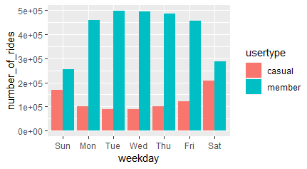

```r
all_trips_v2 %>%
mutate(weekday = wday(start_time, label = TRUE)) %>% group_by(usertype, weekday)%>%summarise(number_of_rides = n(),average_duration = mean(ride_length))%>%arrange(usertype, weekday)  %>%ggplot(aes(x = weekday, y = number_of_rides, fill = usertype))+geom_col(position = "dodge")
```

[figure not shown]

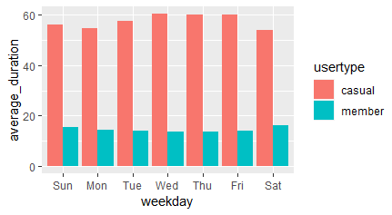

```r
all_trips_v2 %>%mutate(weekday = wday(start_time, label = TRUE))%>%group_by(usertype, weekday) %>%summarise(number_of_rides = n(),average_duration = mean(ride_length))%>%arrange(usertype, weekday)%>%ggplot(aes(x = weekday, y = average_duration, fill = usertype)) + geom_col(position = "dodge")
```

### Conclusions

-Members take more rides throughout the week

-Casual riders take less trips/rides but for longer duration of time

## Act

### Recommendations

Members and casual riders differ in how long they use the bikes and how often they use the bikes. In order to get more casual riders to buy a membership my top recommendations are:

-Give discounts for longer rides when you have a membership

-Longer rides can get some type of rewards program when they become members

-The marketing campaign should be targeted at the popular start and end stations for casual riders.